# Name:Rahul Gupta

Data Science & Business Analytics Internship

Task: Exploratory Data Analysis-Sports(Level-Advanced)

# Importing Libraries

```python
import pandas as pd
import numpy as np
import matplotlib.pyplot as plt
import seaborn as sns
import chart_studio.plotly as py
import cufflinks as cf
%matplotlib inline
```

# Importing Datasets

```python
matches=pd.read_csv("C:/Users/Rahul Gupta/Documents/Dataset/matches.csv")
deliveries=pd.read_csv("C:/Users/Rahul Gupta/Documents/Dataset/deliveries.csv")
```

```python
matches.head()
```

|  | id | season | city | date | team1 | team2 | toss_winner | toss_decision | result | dl_applied | winner | win_by_runs | win_by_wickets | player_of_match | venue | umpire1 | umpire2 | umpire3 |
| --- | --- | --- | --- | --- | --- | --- | --- | --- | --- | --- | --- | --- | --- | --- | --- | --- | --- | --- |
| 0 | 1 | 2017 | Hyderabad | 2017-04-05 | Sunrisers Hyderabad | Royal Challengers Bangalore | Royal Challengers Bangalore | field | normal | 0 | Sunrisers Hyderabad | 35 | 0 | Yuvraj Singh | Rajiv Gandhi International Stadium, Uppal | AY Dandekar | NJ Llong | NaN |
| 1 | 2 | 2017 | Pune | 2017-04-06 | Mumbai Indians | Rising Pune Supergiant | Rising Pune Supergiant | field | normal | 0 | Rising Pune Supergiant | 0 | 7 | SPD Smith | Maharashtra Cricket Association Stadium | A Nand Kishore | S Ravi | NaN |
| 2 | 3 | 2017 | Rajkot | 2017-04-07 | Gujarat Lions | Kolkata Knight Riders | Kolkata Knight Riders | field | normal | 0 | Kolkata Knight Riders | 0 | 10 | CA Lynn | Saurashtra Cricket Association Stadium | Nitin Menon | CK Nandan | NaN |
| 3 | 4 | 2017 | Indore | 2017-04-08 | Rising Pune Supergiant | Kings XI Punjab | Kings XI Punjab | field | normal | 0 | Kings XI Punjab | 0 | 6 | GJ Maxwell | Holkar Cricket Stadium | AK Chaudhary | C Shamshuddin | NaN |
| 4 | 5 | 2017 | Bangalore | 2017-04-08 | Royal Challengers Bangalore | Delhi Daredevils | Royal Challengers Bangalore | bat | normal | 0 | Royal Challengers Bangalore | 15 | 0 | KM Jadhav | M Chinnaswamy Stadium | NaN | NaN | NaN |

```python
deliveries.head()
```

|  | match_id | inning | batting_team | bowling_team | over | ball | batsman | non_striker | bowler | is_super_over | ... | bye_runs | legbye_runs | noball_runs | penalty_runs | batsman_runs | extra_runs | total_runs | player_dismissed | dismissal_kind | fielder |
| --- | --- | --- | --- | --- | --- | --- | --- | --- | --- | --- | --- | --- | --- | --- | --- | --- | --- | --- | --- | --- | --- |
| 0 | 1 | 1 | Sunrisers Hyderabad | Royal Challengers Bangalore | 1 | 1 | DA Warner | S Dhawan | TS Mills | 0 | ... | 0 | 0 | 0 | 0 | 0 | 0 | 0 | NaN | NaN | NaN |
| 1 | 1 | 1 | Sunrisers Hyderabad | Royal Challengers Bangalore | 1 | 2 | DA Warner | S Dhawan | TS Mills | 0 | ... | 0 | 0 | 0 | 0 | 0 | 0 | 0 | NaN | NaN | NaN |
| 2 | 1 | 1 | Sunrisers Hyderabad | Royal Challengers Bangalore | 1 | 3 | DA Warner | S Dhawan | TS Mills | 0 | ... | 0 | 0 | 0 | 0 | 4 | 0 | 4 | NaN | NaN | NaN |
| 3 | 1 | 1 | Sunrisers Hyderabad | Royal Challengers Bangalore | 1 | 4 | DA Warner | S Dhawan | TS Mills | 0 | ... | 0 | 0 | 0 | 0 | 0 | 0 | 0 | NaN | NaN | NaN |
| 4 | 1 | 1 | Sunrisers Hyderabad | Royal Challengers Bangalore | 1 | 5 | DA Warner | S Dhawan | TS Mills | 0 | ... | 0 | 0 | 0 | 0 | 0 | 2 | 2 | NaN | NaN | NaN |

5 rows × 21 columns

```python
#Number of rows and columns
matches.shape
```

```
(756, 18)
```

```python
matches.info()
```

```
<class 'pandas.core.frame.DataFrame'>
RangeIndex: 756 entries, 0 to 755
Data columns (total 18 columns):
 #   Column           Non-Null Count  Dtype
---  ------           --------------  -----
 0   id               756 non-null    int64
 1   season           756 non-null    int64
 2   city             749 non-null    object
 3   date             756 non-null    object
 4   team1            756 non-null    object
 5   team2            756 non-null    object
 6   toss_winner      756 non-null    object
 7   toss_decision    756 non-null    object
 8   result           756 non-null    object
 9   dl_applied       756 non-null    int64
 10  winner           752 non-null    object
 11  win_by_runs      756 non-null    int64
 12  win_by_wickets   756 non-null    int64
 13  player_of_match  752 non-null    object
 14  venue            756 non-null    object
 15  umpire1          754 non-null    object
 16  umpire2          754 non-null    object
 17  umpire3          119 non-null    object
dtypes: int64(5), object(13)
memory usage: 106.4+ KB
```

```python
matches.columns
```

```
Index(['id', 'season', 'city', 'date', 'team1', 'team2', 'toss_winner',
       'toss_decision', 'result', 'dl_applied', 'winner', 'win_by_runs',
       'win_by_wickets', 'player_of_match', 'venue', 'umpire1', 'umpire2',
       'umpire3'],
      dtype='object')
```

```python
matches.isna().any()
```

```
id                 False
season             False
city                True
date               False
team1              False
team2              False
toss_winner        False
toss_decision      False
result             False
dl_applied         False
winner              True
win_by_runs        False
win_by_wickets     False
player_of_match     True
venue              False
umpire1             True
umpire2             True
umpire3             True
dtype: bool
```

```python
matches.isna().sum()
```

```
id                   0
season               0
city                 7
date                 0
team1                0
team2                0
toss_winner          0
toss_decision        0
result               0
dl_applied           0
winner               4
win_by_runs          0
win_by_wickets       0
player_of_match      4
venue                0
umpire1              2
umpire2              2
umpire3            637
dtype: int64
```

```python
matches=matches.drop(columns='umpire3',axis=1)
```

```python
deliveries.shape
```

```
(179078, 21)
```

```python
deliveries.info()
```

```
<class 'pandas.core.frame.DataFrame'>
RangeIndex: 179078 entries, 0 to 179077
Data columns (total 21 columns):
 #   Column            Non-Null Count   Dtype
---  ------            --------------   -----
 0   match_id          179078 non-null  int64
 1   inning            179078 non-null  int64
 2   batting_team      179078 non-null  object
 3   bowling_team      179078 non-null  object
 4   over              179078 non-null  int64
 5   ball              179078 non-null  int64
 6   batsman           179078 non-null  object
 7   non_striker       179078 non-null  object
 8   bowler            179078 non-null  object
 9   is_super_over     179078 non-null  int64
 10  wide_runs         179078 non-null  int64
 11  bye_runs          179078 non-null  int64
 12  legbye_runs       179078 non-null  int64
 13  noball_runs       179078 non-null  int64
 14  penalty_runs      179078 non-null  int64
 15  batsman_runs      179078 non-null  int64
 16  extra_runs        179078 non-null  int64
 17  total_runs        179078 non-null  int64
 18  player_dismissed  8834 non-null    object
 19  dismissal_kind    8834 non-null    object
 20  fielder           6448 non-null    object
dtypes: int64(13), object(8)
memory usage: 28.7+ MB
```

```python
matches['team1'].unique()
```

```
array(['Sunrisers Hyderabad', 'Mumbai Indians', 'Gujarat Lions',
       'Rising Pune Supergiant', 'Royal Challengers Bangalore',
       'Kolkata Knight Riders', 'Delhi Daredevils', 'Kings XI Punjab',
       'Chennai Super Kings', 'Rajasthan Royals', 'Deccan Chargers',
       'Kochi Tuskers Kerala', 'Pune Warriors', 'Rising Pune Supergiants',
       'Delhi Capitals'], dtype=object)
```

# Data Cleaning & Data Manipulation

```python
for i in range(0,matches.shape[0]):
    if matches['team1'][i]=='Deccan Chargers':
        matches['team1'][i]='Sunrisers Hyderabad'
    if matches['team2'][i]=='Deccan Chargers':
        matches['team2'][i]='Sunrisers Hyderabad'
    if matches['toss_winner'][i]=='Deccan Chargers':
        matches['toss_winner'][i]='Sunrisers Hyderabad'
    if matches['winner'][i]=='Deccan Chargers':
        matches['winner'][i]='Sunrisers Hyderabad'
    if (matches['team1'][i]=='Rising Pune Supergiant')|(matches['team1'][i]=='Pune Warriors'):
        matches['team1'][i]='Rising Pune Supergiants'
    if (matches['team2'][i]=='Rising Pune Supergiant')|(matches['team2'][i]=='Pune Warriors'):
        matches['team2'][i]='Rising Pune Supergiants'
    if (matches['toss_winner'][i]=='Rising Pune Supergiant')|(matches['toss_winner'][i]=='Pune Warriors'):
        matches['toss_winner'][i]='Rising Pune Supergiants'
    if (matches['winner'][i]=='Rising Pune Supergiant')|(matches['winner'][i]=='Pune Warriors'):
        matches['winner'][i]='Rising Pune Supergiants'
    if matches['team1'][i]=='Delhi Daredevils':
        matches['team1'][i]='Delhi Capitals'
    if matches['team1'][i]=='Delhi Daredevils':
        matches['team2'][i]='Delhi Capitals'
    if matches['toss_winner'][i]=='Delhi Daredevils':
        matches['toss_winner'][i]='Delhi Capitals'
    if matches['winner'][i]=='Delhi Daredevils':
        matches['winner'][i]='Delhi Capitals'
```

```python
deliveries['batting_team'].unique()
```

```
array(['Sunrisers Hyderabad', 'Royal Challengers Bangalore',
       'Mumbai Indians', 'Rising Pune Supergiant', 'Gujarat Lions',
       'Kolkata Knight Riders', 'Kings XI Punjab', 'Delhi Daredevils',
       'Chennai Super Kings', 'Rajasthan Royals', 'Deccan Chargers',
       'Kochi Tuskers Kerala', 'Pune Warriors', 'Rising Pune Supergiants',
       'Delhi Capitals'], dtype=object)
```

```python
for i in range(0,deliveries.shape[0]):
    if deliveries['batting_team'][i]=='Deccan Chargers':
        deliveries['batting_team'][i]='Sunrisers Hyderabad'
    if deliveries['bowling_team'][i]=='Deccan Chargers':
        deliveries['bowling_team'][i]='Sunrisers Hyderabad'
    if (deliveries['batting_team'][i]=='Rising Pune Supergiant')|(deliveries['batting_team'][i]=='Pune Warriors'):
        deliveries['batting_team'][i]='Rising Pune Supergiants'
    if (deliveries['bowling_team'][i]=='Rising Pune Supergiant')|(deliveries['bowling_team'][i]=='Pune Warriors'):
        deliveries['bowling_team'][i]='Rising Pune Supergiants'
    if deliveries['batting_team'][i]=='Delhi Daredevils':
        deliveries['batting_team'][i]='Delhi Capitals'
    if deliveries['bowling_team'][i]=='Delhi Daredevils':
        deliveries['bowling_team'][i]='Delhi Capitals'
```

```python
matches.describe()
```

|  | id | season | dl_applied | win_by_runs | win_by_wickets |
| --- | --- | --- | --- | --- | --- |
| count | 756.000000 | 756.000000 | 756.000000 | 756.000000 | 756.000000 |
| mean | 1792.178571 | 2013.444444 | 0.025132 | 13.283069 | 3.350529 |
| std | 3464.478148 | 3.366895 | 0.156630 | 23.471144 | 3.387963 |
| min | 1.000000 | 2008.000000 | 0.000000 | 0.000000 | 0.000000 |
| 25% | 189.750000 | 2011.000000 | 0.000000 | 0.000000 | 0.000000 |
| 50% | 378.500000 | 2013.000000 | 0.000000 | 0.000000 | 4.000000 |
| 75% | 567.250000 | 2016.000000 | 0.000000 | 19.000000 | 6.000000 |
| max | 11415.000000 | 2019.000000 | 1.000000 | 146.000000 | 10.000000 |

```python
matches['season'].unique()
```

```
array([2017, 2008, 2009, 2010, 2011, 2012, 2013, 2014, 2015, 2016, 2018,
       2019], dtype=int64)
```

Which IPL team won by scoring the maximum runs?

```python
matches.iloc[matches['win_by_runs'].idxmax()]
```

```
id                               44
season                         2017
city                          Delhi
date                     2017-05-06
team1                Mumbai Indians
team2              Delhi Daredevils
toss_winner          Delhi Capitals
toss_decision                 field
result                       normal
dl_applied                        0
winner               Mumbai Indians
win_by_runs                     146
win_by_wickets                    0
player_of_match         LMP Simmons
venue              Feroz Shah Kotla
umpire1                 Nitin Menon
umpire2                   CK Nandan
Name: 43, dtype: object
```

Which IPL team won by maximum number of wickets?

```python
matches.iloc[matches['win_by_wickets'].idxmax()]
```

```
id                                                      3
season                                               2017
city                                               Rajkot
date                                           2017-04-07
team1                                       Gujarat Lions
team2                               Kolkata Knight Riders
toss_winner                         Kolkata Knight Riders
toss_decision                                       field
result                                             normal
dl_applied                                              0
winner                              Kolkata Knight Riders
win_by_runs                                             0
win_by_wickets                                         10
player_of_match                                   CA Lynn
venue              Saurashtra Cricket Association Stadium
umpire1                                       Nitin Menon
umpire2                                         CK Nandan
Name: 2, dtype: object
```

Which season consisted of the highest number of matches ever played?

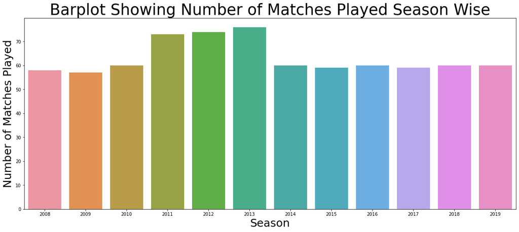

```python
fig_dims=(20,8)
fig,ax=plt.subplots(figsize=fig_dims)
sns.countplot(x='season',ax=ax,data=matches)
plt.xlabel("Season",size=25)
plt.ylabel("Number of Matches Played",size=25)
plt.title("Barplot Showing Number of Matches Played Season Wise",size=35)
```

- Maximum number of matches are being played in 2013 followed by 2012 and 2011. In rest of the sesons the number of matches played is approximately same.

Which is the most successful IPL team?

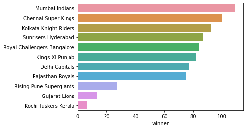

```python
data=matches['winner'].value_counts()
sns.barplot(y=data.index,x=data)
```

- Thus we can see that 'Mumbai Indians' is the most successful IPL team followed by 'Chennai Super Kings'.

Which is the most successful toss winner?

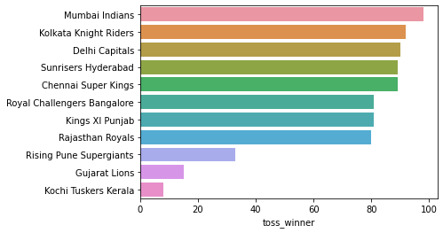

```python
data=matches['toss_winner'].value_counts()
sns.barplot(x=data,y=data.index)
```

- We can see that 'Mumbai Indians' is the most successful toss winners followed by 'Kolkata Knight Riders' and 'Delhi Capitals'. Whereas 'Kochi Tuskers Kerala' and 'Gujarat Lions' are not so good at toss.

What is the impact of 'toss_decision' on winning a match?

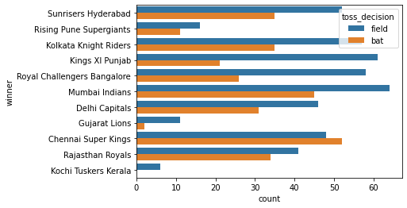

```python
sns.countplot(y='winner',hue='toss_decision',data=matches)
```

- From the above barplot it can be seen that all the teams (except 'Chennai Super Kings') won the matches maximum number of times when they chose field. Thus in IPL choosing field first gives upper hand in winning the match.

Which team played maximum number of matches in all seasons of IPL?

```python
teams=matches['team1'].append(matches['team2'])
```

```python
number_of_matches_played=teams.value_counts()
```

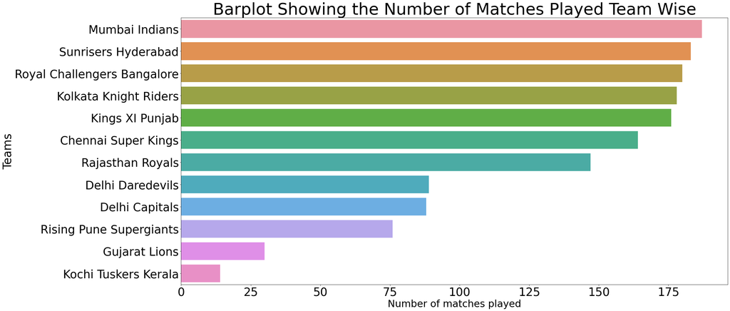

```python
fig,ax=plt.subplots(figsize=(30,15))
sns.barplot(y=number_of_matches_played.index,x=number_of_matches_played)
plt.ylabel('Teams',fontdict={'fontsize':35})
plt.xlabel("Number of matches played",fontdict={'fontsize':30})
plt.title('Barplot Showing the Number of Matches Played Team Wise',fontdict={'fontsize':50})
plt.rcParams.update({'font.size':35})
plt.show()
```

- We can see that 'Mumbai Indians' have played maximum number of matches in IPL followed by 'Sunrisers Hyderabad'. While 'Kochi Tuskers Kerala' have played very few matches in comparison to other teams and thus it is quiet obvious that they have won least number of matches.

What is the chance of winning a match after wining the toss?

```python
number_of_win=matches['toss_winner']==matches['winner']
number_of_win.groupby(number_of_win).size()
```

```
False    363
True     393
dtype: int64
```

```
C:\Users\Rahul Gupta\anaconda3\envs\PyR\lib\site-packages\seaborn\_decorators.py:36: FutureWarning:

Pass the following variable as a keyword arg: x. From version 0.12, the only valid positional argument will be `data`, and passing other arguments without an explicit keyword will result in an error or misinterpretation.
```

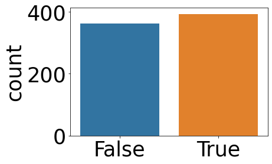

```python
sns.countplot(number_of_win)
```

- We can see that the number of times toss as well as match won do not differ from the other. Hence we can say winning the toss in IPL do not ensure winning the match.

Number of win by teams per season

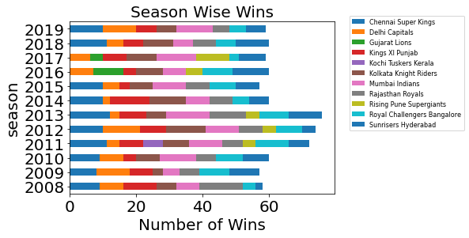

```python
season_wise_win=pd.crosstab(index=matches['season'],columns=matches['winner'])
plt.figure(figsize=(8,8))
season_wise_win.plot(kind='barh',stacked=True)
plt.xlabel("Number of Wins")
plt.title("Season Wise Wins",size=20)
plt.legend(loc=7,prop={'size': 8},bbox_to_anchor = (1.50, 0.7))
```

Man of the match-Highest to lowest(in won matches)

```python
man_of_the_match=matches['player_of_match'].value_counts()
```

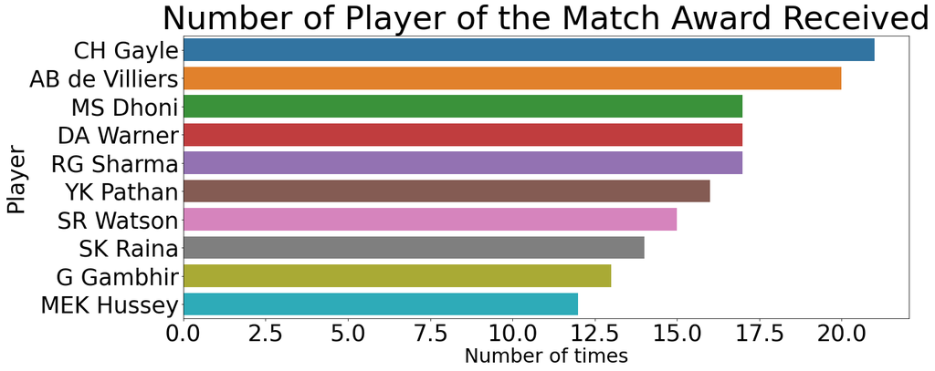

```python
fig,ax=plt.subplots(figsize=(20,8))
sns.barplot(y=man_of_the_match.index[0:10],x=man_of_the_match[0:10])
plt.ylabel('Player',fontdict={'fontsize':35})
plt.xlabel("Number of times",fontdict={'fontsize':30})
plt.title('Number of Player of the Match Award Received',fontdict={'fontsize':50})
plt.rcParams.update({'font.size':40})
plt.show()
```

- Players like 'CH Gayle','AB de Villiers','MS Dhoni','RG Sharma' and 'DA Warner' are the top 5 players who won maximum number of player of the match award.

Best Batsman(Interms of Runs Scored)

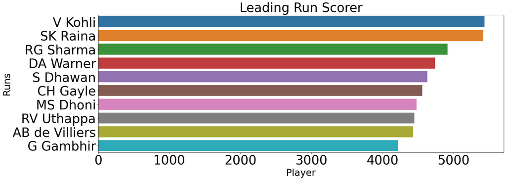

```python
best_batsman=deliveries.groupby(['batsman']).batsman_runs.sum().reset_index()
best_batsman=best_batsman.sort_values(by='batsman_runs',ascending=False).head(10)
plt.figure(figsize=(23,8))
sns.barplot(y='batsman',x='batsman_runs',data=best_batsman)
plt.title("Leading Run Scorer",fontdict={'fontsize':40})
plt.xlabel("Player",size=30)
plt.ylabel("Runs",size=30)
```

- So the player with maximum runs in the history of IPL is 'Virat Kohli' followed by 'Suresh Raina' and then followed by 'Rohit Sharma' and so on. Thus these players play important for their team.

Best Batsman(In terms of Strike Rate)

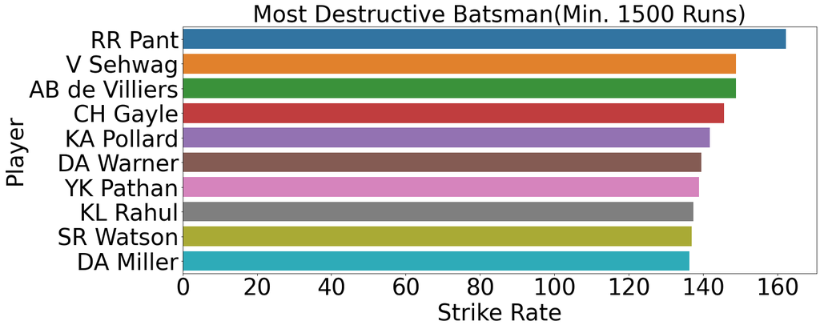

```python
strike_rate=deliveries.groupby('batsman').batsman_runs.sum().reset_index()
strike_rate['balls']=deliveries.groupby('batsman').ball.count().reset_index()['ball']
strike_rate['rate']=strike_rate['batsman_runs']/strike_rate['balls']*100
strike_rate=strike_rate[strike_rate['batsman_runs']>=1500].sort_values(by=['rate'],ascending=False).head(10)
plt.figure(figsize=(20,8))
sns.barplot(y='batsman',x='rate',data=strike_rate)
plt.xlabel("Strike Rate")
plt.ylabel("Player")
plt.title("Most Destructive Batsman(Min. 1500 Runs)",fontdict={'fontsize':40})
```

- In T20 cricket a player with high strike rate is most valuable. We can see that 'Rishabh Pant' have highest strike rate thus he is most valuable and destructive batsman in IPL followed by 'Virendra Sehwag' and 'AB de Villiers'.

Best Bowlers(In terms of Economy)

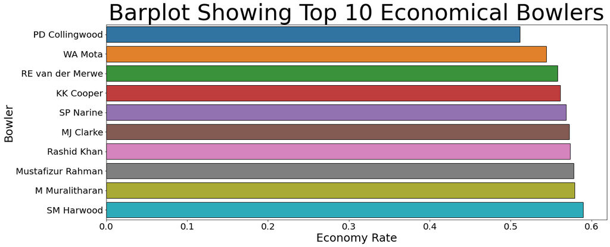

```python
economy=deliveries.groupby('bowler').sum()
economy['over']=economy['over']/6
economy['runs']=economy['wide_runs']+economy['noball_runs']+economy['batsman_runs']
economy=economy[economy['over']>=100]
economy['rate']=economy['runs']/economy['over']
economy=economy.sort_values(by='rate',ascending=True).head(10)

plt.figure(figsize=(20,8))
plt.rcParams.update({'font.size':20})
sns.barplot(x=economy['rate'],y=economy.index,edgecolor='black')
plt.xlabel("Economy Rate",size=25)
plt.ylabel("Bowler",size=25)
plt.title("Barplot Showing Top 10 Economical Bowlers",fontdict={'fontsize':50})
```

- Players like 'PD Collingwood', 'WL Mota' & 'RE van der Merwe' are the most economical bowlers who concede very less runs.

Best Bowlers(In Terms of Wickets)

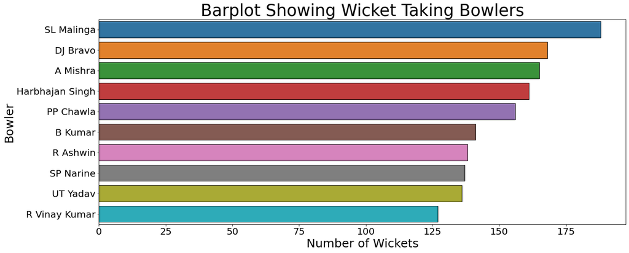

```python
dismissals=['caught','bowled','run out','lbw','caught and bowled','stumped','retired hurt','hit wicket','obstructing the field']
wicket=deliveries[deliveries['dismissal_kind'].isin(dismissals)]
wicket=wicket['bowler'].value_counts().reset_index().head(10)
wicket.columns=['bowler','wickets']

plt.figure(figsize=(20,8))
sns.barplot(x='wickets',y='bowler',data=wicket,edgecolor='black')
plt.xlabel("Number of Wickets",size=25)
plt.ylabel("Bowler",size=25)
plt.title("Barplot Showing Wicket Taking Bowlers",size=35)
```

- Bowlers like 'SL Malinga', 'DJ Bravo' and 'A Mishra' are the top 3 bowlers. These bowlers are most destructive.

# Final Conclusion:

From the above analysis we can conclude that:

- In IPL most successful teams are 'Mumbai Indians' and 'Chennai Super Kings'.
- The teams won maximum number of matches when they chose field first.
- Players like 'Virat Kohli', 'Suresh Raina' and 'Rohit Sharma' are top three run scorer in IPL.
- In terms of strike rate, players like 'Rishabh Pant', 'Virendra Sehwag' and 'AB de Villiars' are the most striking batsman.
- 'CH Gayle', 'AB de Villiars' and 'MS Dhoni' are top three players who received maximum number of man of the match.
- Bowlers like 'Paul Collingwood' and 'WA Mota' are the most economical bowlers.
- 'SL Malinga', 'DJ Bravo' and 'A Mishra' are leading wicket takers.
- So companies can endorse teams like 'Mumbai Indians' and 'Chennai Super Kings' for their products.
- Companies can endorse players like 'Virat Kohli', 'Suresh Raina', 'Rohit Sharma', 'Rishabh Pant', 'Virendra Shewag', 'AB de Villiars','MS Dhoni', 'CH Gayle', 'Paul Collingwood', 'WA Mota', 'SL Malinga', 'DJ Bravo' and 'A Mishra' for their products.